# Analysis Procedure

Marco Torchiano

19 November 2015

Computes the average power for the working tasks in a series of measures.

The computation assumes the execution follows a well defined protocol to mark tasks begin and end. A typical profile is:

```
       --------      --v-^v^--
       |      |      |       |
       |      |      |       |
 -------      --------       -....
  SLEEP: WAIT :SLEEP : WORK  :
```

`SLEEP` : is a period of sleep for a given (marker.length) time

`WAIT` : is a period of busy waiting for a given (marker.length) time

`WORK` : is a period of actual work (the one we aim to measure the energy consumption of)

## Load data

The analysis procedure can be applied on data containing Power samples.

Typically file containing current (`I`) values (expressed in Ampere) is the starting point.

The power, given a *constant* `voltage` in output from the generator (5.03 V) – can be computer using the basic relation

$P=V \cdot I$

```r
  filepath = "data/syscall_mmap2.txt"
  #filepath = "data/syscall_futex.txt"
  #filepath = "data/syscall_gettimeofday.txt"
  #filepath = "data/syscall_mprotect.txt"
  voltage = 5.03 ## Volt

  # read the file containing current values (in A)
  data = read.delim2(filepath, header = FALSE, skip = 7)
  names(data)="I"

#  data = read.csv("~/Dropbox/PhDRifat/ENERGY ESEM 2015/Samples/Java/JavaBubble10000.csv")
#  names(data)[2]="I"
#  marker.length=1000

  # compute the power
  data$P <- with(data, I*voltage )
```

## Input parameters

The algorithm takes the following input parameters:

```r
adjust = 1.5 ## density parameter
marker.length = 5000
marker.tolerance= 0.1
N = 30 # number of task markers
```

## Density analysis

Compute the distribution density of the instant power in order to identify the typical working levels.

```r
  ## Distribution density of values
  dens <- density(data$P,adjust=adjust)
  #dens <- density(data$P)

  ## Find peaks in the distribution (the most common power levels)
  dens$peaks <- which(peaks(dens$y) & dens$y>mean(dens$y))

  ## Identify thresholds between peaks as the points of minimum density between peaks
  thresholds = dens$x[apply(cbind(head(dens$peaks,-1),tail(dens$peaks,-1)),1,function(x){
    ss = dens$y[x[1]:x[2]]
    x[1] + which(ss == min(ss))
  })]

  baseline = dens$x[dens$peaks[1]]
```

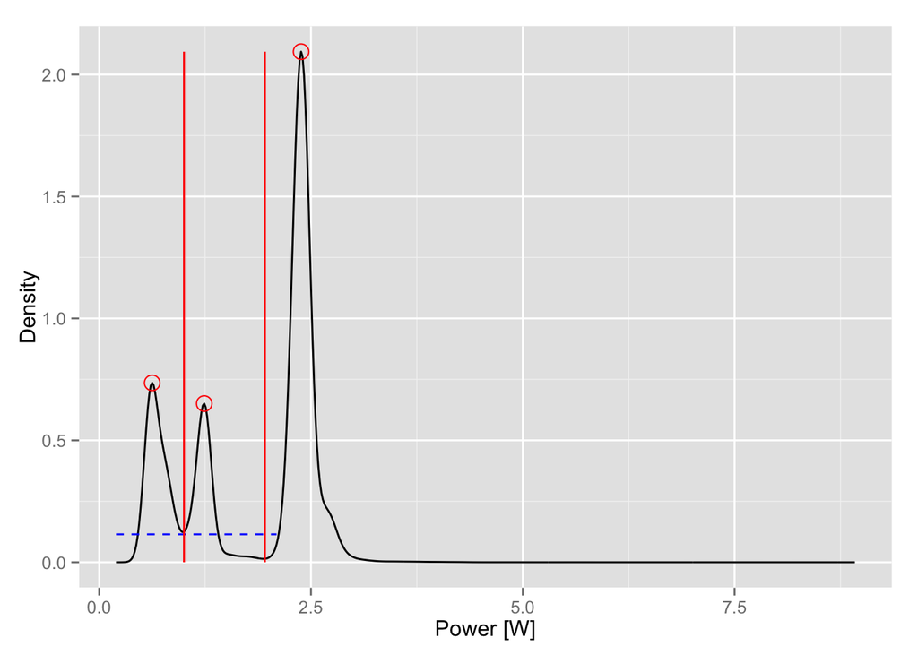

The baseline, representing the idle level of consumption correspond to the first peak in the density plot: 0.6256976 W.

## Tagging

Each peak is assigned to a level, the the thresholds are used to discriminate between consecutive levels. The data points are tagged with the level name.

The tagging indetify runs of consecutive points having the same level. The runs are then identified with a unique number.

To avoid manipulating the whole series of points, a summary table is computed that reports:

- tag
- run ID
- length
- start position
- end position

```r
  ## tag levels are those corresponding to peaks plus a special NOISE tag
  tag.levels <- paste0("L",seq(dens$peaks))
  data$tag <- factor(tag.levels[findInterval(data$P,c(0,thresholds))],c(tag.levels,"NOISE"))

  ## assign unique id to runs
  data$runid <- cumsum(c(1,abs(diff(as.numeric(data$tag))!=0) ) )

  ## build run summary table
  id.tab = subset(melt(with(data,table(tag,runid)),id.vars="runid",value.name="length"),length!=0)
  id.tab$start=cumsum(c(1,head(id.tab$length,-1)))
  id.tab$end=cumsum(id.tab$length)
```

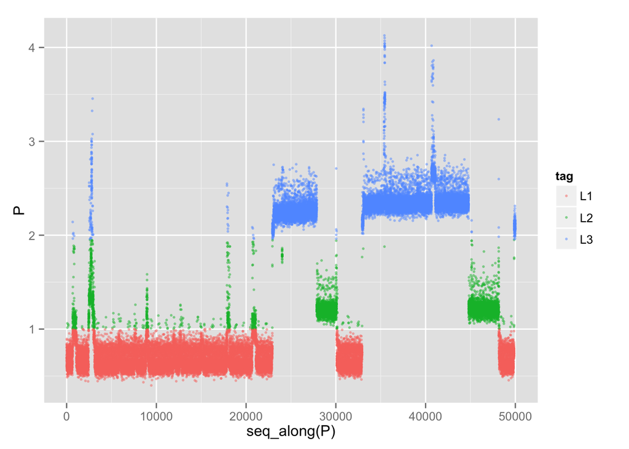

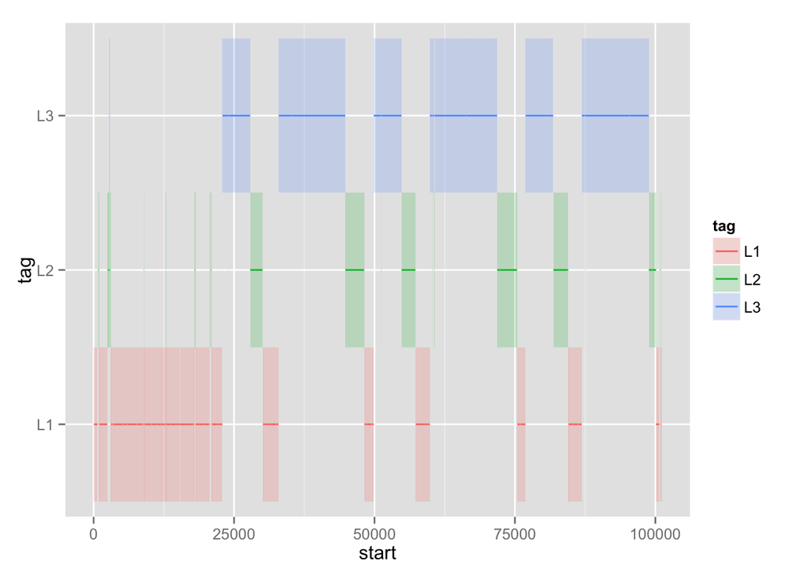

## Denoise

The collected measures are subject to noise (as any measure is). Generally there are series of a few points that have a different value.

```r
  dens = density(id.tab$length)
  dens$peaks <- which(peaks(dens$y) & dens$y>mean(dens$y))

  ## Identify thresholds between peaks as the points of minimum density between peaks
  thresholds = dens$x[apply(cbind(head(dens$peaks,-1),tail(dens$peaks,-1)),1,function(x){
    ss = dens$y[x[1]:x[2]]
    x[1] + which(ss == min(ss))
  })]
  noise=thresholds[1]
```

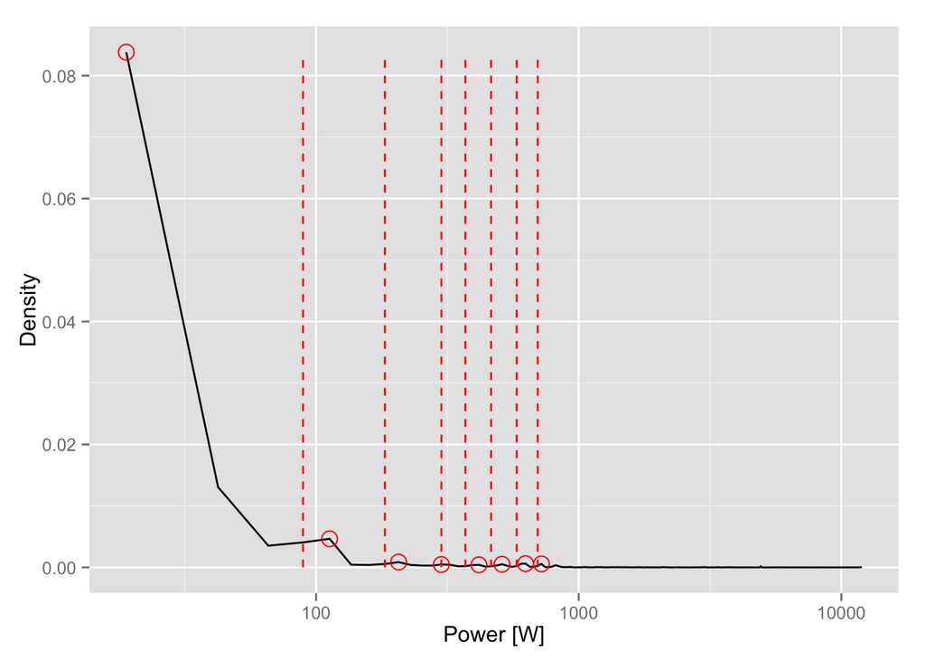

A possible suggested threshold for noise is: 89.2087986

In most cases the nois is a small variation around the expected value. Though, in some cases the noise is so large to cause a different tag to be assigned.

We have, first, to identify the noise using a `noise` threshold on the lenght of the runs.

```r
  ## identify noise runs by means of a run length threshold
  id.tab$tag[id.tab$length<noise] = "NOISE"
```

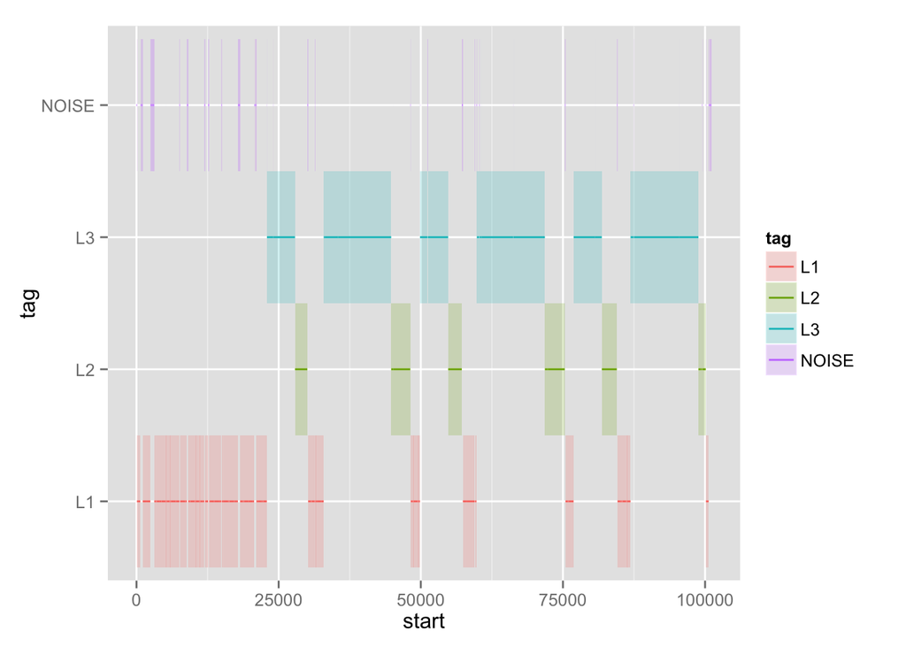

Then, we can remove the noise using some strategy:

- merge noise run with the preceding run
- merge the noise run with either the preceding or the following one, depending which is the largest.

```r
  ## Remove noise
  if(id.tab$tag[1]=="NOISE"){
    id.tab$tag[1] = id.tab$tag[min(id.tab$runid[id.tab$tag!="NOISE"])]
  }
  id.noise = which(id.tab$tag=="NOISE")
  while(length(id.noise)>0){
    ##  assign the noise run the same level as the  the preceding run
    id.tab$tag[id.noise] = id.tab$tag[id.noise-1]
    id.noise = which(id.tab$tag=="NOISE")
  }
  ## id.tab = id.tab[order(id.tab$runid),] ### probably not useful

  ## Merge consecutive runs havin the same tag
  ## a) recompute the run id
  id.tab$runid = cumsum(c(1,abs(diff(as.numeric(id.tab$tag))!=0) ) )
  ## b) merge all the fragments with the same runid
  id.tab = ddply(id.tab,.(runid,tag),summarize,
                 length = sum(length),
                 start = min(start),
                 end = max(end)
                 )
```

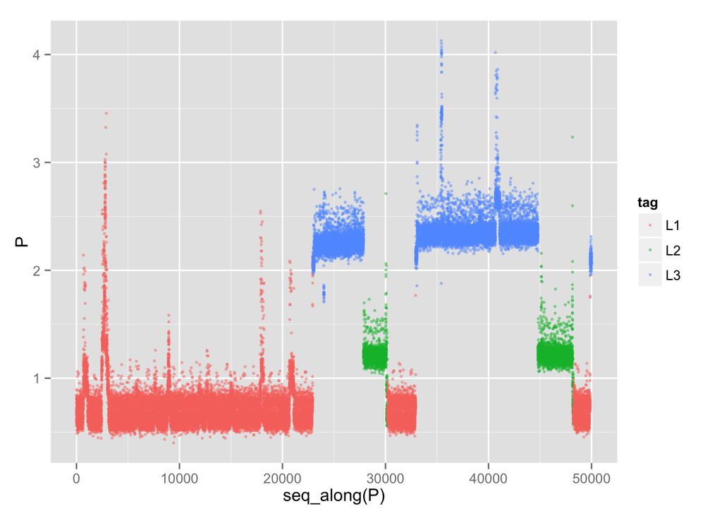

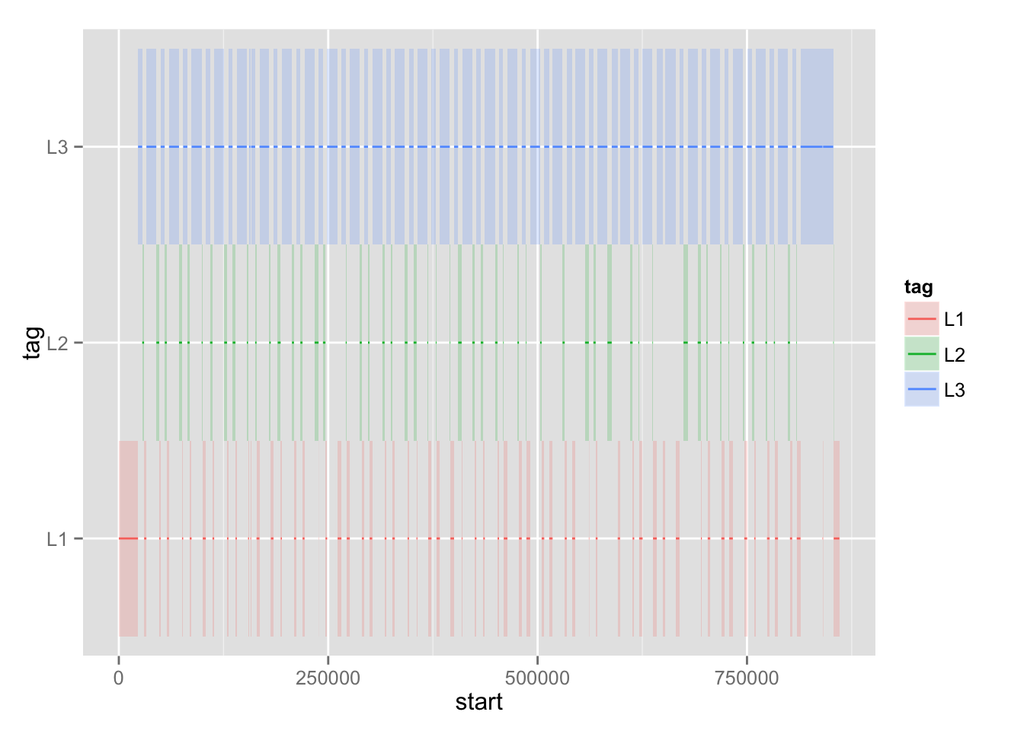

| runid | tag | length | start | end |
| --- | --- | --- | --- | --- |
| 1 | L1 | 22947 | 1 | 22947 |
| 2 | L3 | 4922 | 22948 | 27869 |
| 3 | L2 | 2315 | 27870 | 30184 |
| 4 | L1 | 2742 | 30185 | 32926 |
| 5 | L3 | 11874 | 32927 | 44800 |
| 6 | L2 | 3423 | 44801 | 48223 |
| 7 | L1 | 1646 | 48224 | 49869 |
| 8 | L3 | 4935 | 49870 | 54804 |
| 9 | L2 | 2588 | 54805 | 57392 |
| 10 | L1 | 2474 | 57393 | 59866 |

## Identify task markers

Then we need to identify the marker that introduce the experiment.

We do not make any hypothesis as to the level at which markers are found (it should be the highest one…)

The markers are (a subset of) the runs whose lenght is close to the predefined marker length.

First we need to understand at which level (tag) are located the markers.

For each distinct level/run:

- Count how many runs are in the expected range (the interval centered around `marker.length` with emiwidth `marker.tolerance`).
- Compute the median period separating two consecutive runs
- Compute the standard deviation of the period separating two consecutive runs
- Select as marker level/tag the one with the number of potential markers, closer to the expected value (`N`) and with the smallest variability around of the period.

```r
  l.min = marker.length*(1-marker.tolerance)
  l.max = marker.length*(1+marker.tolerance)
  markers = subset(id.tab,length>=l.min & length<=l.max)
  mark.sum = ddply(markers,.(tag),summarize,
        n=length(tag),
        length = median(length),
        t= median(diff(start)),
#        tv = sd(diff(start))
#        tv = 2*diff(quantile(diff(start),c(.25,.75)))
        tv = median(diff(start))*.1
        )
  mark.sum$score = dim(mark.sum)[1]*(rank(abs(mark.sum$n-N))-1)+rank(mark.sum$tv)-1
  marker = subset(mark.sum,score==min(score))
  marker.tag = marker$tag

  kable(mark.sum)
```

| tag | n | length | t | tv | score |
| --- | --- | --- | --- | --- | --- |
| L1 | 3 | 4525.0 | 274076.5 | 27407.65 | 8 |
| L2 | 4 | 4960.0 | 90771.0 | 9077.10 | 4 |
| L3 | 26 | 4939.5 | 26959.0 | 2695.90 | 0 |

- the initial set of markers are the runs in the expected range
- the we proceed with all the markers trying to find the next one either in the existing set of markers or in the runs with the market tag

```r
  potential.markers = subset(id.tab,tag==marker$tag)

  selected.markers = c()
  initial.markers = subset(markers,tag==marker$tag)
  print(initial.markers$runid)
```

```
##  [1]   2   8  14  20  26  34  40  46  52  57  63  69  75  81  87  93  99
## [18] 105 121 131 141 146 152 158 164 170
```

```r
  generation = 0
  while(!is.null(initial.markers)){
    generation <- generation + 1
    if(generation > 5) break
    new.markers=c()
    for(id in initial.markers$runid){
      #cat(id,"\n")
      current.marker = subset(potential.markers,runid==id)
      t.expected = current.marker$start + marker$t
      t.lower = t.expected - marker$tv
      t.upper = t.expected + marker$tv

      successor = subset(potential.markers,start>=t.lower & start<=t.upper & length>marker.length/2)
      if(dim(successor)[1]>0){
        if(dim(successor)[1]>1){
          successor <- subset(successor,abs(length-marker.length)==min(abs(length-marker.length)))
          #stop("No strategy to prioritize defined yet!!")
        }
        if(! successor$runid%in%selected.markers$runid){
          new.markers <- rbind(new.markers,successor)
        }
      }

      t.expected = current.marker$start - marker$t
      t.lower = t.expected - marker$tv
      t.upper = t.expected + marker$tv
      predecessor = subset(potential.markers,start>=t.lower & start<=t.upper& length>marker.length/2)
      if(dim(predecessor)[1]>0){
        if(dim(predecessor)[1]>1){
          predecessor <- subset(predecessor,abs(length-marker.length)==min(abs(length-marker.length)))
        }
        if(! predecessor$runid%in%selected.markers$runid){
          new.markers <- rbind(new.markers,predecessor)
        }
      }
    }
    new.markers = unique(new.markers)
    initial.markers=new.markers
    if(!is.null(new.markers)){
      print(new.markers$runid)

      new.markers$Gen = generation
      selected.markers=rbind(selected.markers,new.markers)
    }
  }
```

```
##  [1]   8  14   2  20  26  34  40  46  52  57  63  69  75  81  87  93  99
## [18] 105 111 126 116 137 146 152 141 158 164 170
## [1] 131 121
```

```r
  selected.markers <- unique(selected.markers)
  selected.markers <- selected.markers[order(selected.markers$runid),]
```

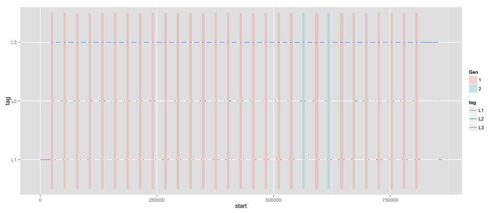

The procedure identified 30 markers. The average length of markers is 5202.3666667, median: 4942, sd: 594.3077389.

|  | runid | tag | length | start | end | Gen |
| --- | --- | --- | --- | --- | --- | --- |
| 2 | 2 | L3 | 4922 | 22948 | 27869 | 1 |
| 8 | 8 | L3 | 4935 | 49870 | 54804 | 1 |
| 14 | 14 | L3 | 4946 | 76886 | 81831 | 1 |
| 20 | 20 | L3 | 4933 | 103900 | 108832 | 1 |
| 26 | 26 | L3 | 4937 | 130909 | 135845 | 1 |
| 34 | 34 | L3 | 4943 | 157859 | 162801 | 1 |
| 40 | 40 | L3 | 4938 | 184709 | 189646 | 1 |
| 46 | 46 | L3 | 4939 | 211727 | 216665 | 1 |
| 52 | 52 | L3 | 4938 | 238747 | 243684 | 1 |
| 57 | 57 | L3 | 5096 | 265785 | 270880 | 1 |
| 63 | 63 | L3 | 4937 | 292589 | 297525 | 1 |
| 69 | 69 | L3 | 4942 | 319547 | 324488 | 1 |
| 75 | 75 | L3 | 5392 | 346489 | 351880 | 1 |
| 811 | 81 | L3 | 4992 | 373369 | 378360 | 1 |
| 87 | 87 | L3 | 4942 | 400259 | 405200 | 1 |
| 93 | 93 | L3 | 5003 | 427060 | 432062 | 1 |
| 99 | 99 | L3 | 4940 | 454008 | 458947 | 1 |
| 105 | 105 | L3 | 4933 | 480985 | 485917 | 1 |
| 111 | 111 | L3 | 5862 | 507947 | 513808 | 1 |
| 116 | 116 | L3 | 6348 | 534817 | 541164 | 1 |
| 121 | 121 | L3 | 4942 | 561628 | 566569 | 2 |
| 126 | 126 | L3 | 7098 | 588477 | 595574 | 1 |
| 131 | 131 | L3 | 4936 | 615369 | 620304 | 2 |
| 137 | 137 | L3 | 7008 | 642299 | 649306 | 1 |
| 1411 | 141 | L3 | 4935 | 669240 | 674174 | 1 |
| 146 | 146 | L3 | 5053 | 696128 | 701180 | 1 |
| 152 | 152 | L3 | 4944 | 723087 | 728030 | 1 |
| 158 | 158 | L3 | 5481 | 750060 | 755540 | 1 |
| 164 | 164 | L3 | 4937 | 777058 | 781994 | 1 |
| 170 | 170 | L3 | 4919 | 803906 | 808824 | 1 |

## Identify work

For each marker, identify the beginning and end of the work run.

Possible options:

1. **End + T *to* Start - T** (E2S): Skip a `marker.length` after marker *end*: that’s the beginning of a work; stop `marker.length` before the next marker *start*

```r
work = data.frame(
      start = head(selected.markers,-1)$end+marker.length,
      end = tail(selected.markers,-1)$start-marker.length
      )
work <- within(work,
       length <- end-start
       )
summary(work)
```

```
##      start             end             length
##  Min.   : 32869   Min.   : 44870   Min.   : 9795
##  1st Qu.:221665   1st Qu.:233747   1st Qu.:11860
##  Median :410200   Median :422060   Median :11954
##  Mean   :410341   Mean   :422059   Mean   :11718
##  3rd Qu.:600574   3rd Qu.:610369   3rd Qu.:12030
##  Max.   :786994   Max.   :798906   Max.   :12101
```

```r
work.run = data.frame(
      start = head(selected.markers,-1)$start+2*marker.length,
      end = tail(selected.markers,-1)$start-marker.length
      )
work.run <- within(work.run,
       length <- end-start+1
       )
summary(work.run)
```

```
##      start             end             length
##  Min.   : 32948   Min.   : 44870   Min.   :11802
##  1st Qu.:221727   1st Qu.:233747   1st Qu.:11881
##  Median :410259   Median :422060   Median :11943
##  Mean   :410130   Mean   :422059   Mean   :11931
##  3rd Qu.:598477   3rd Qu.:610369   3rd Qu.:11978
##  Max.   :787058   Max.   :798906   Max.   :12039
```

The second approach consistently gives better and more consistent results.

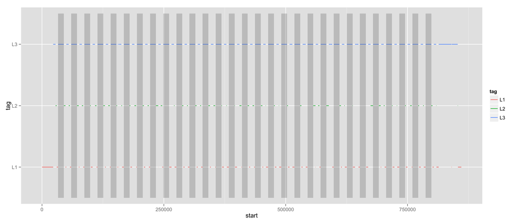

## Extract work data

```r
work.run$P <- apply(work.run,1,function(x)
                      mean(data[x["start"]:x["end"],]$P)-baseline)
```

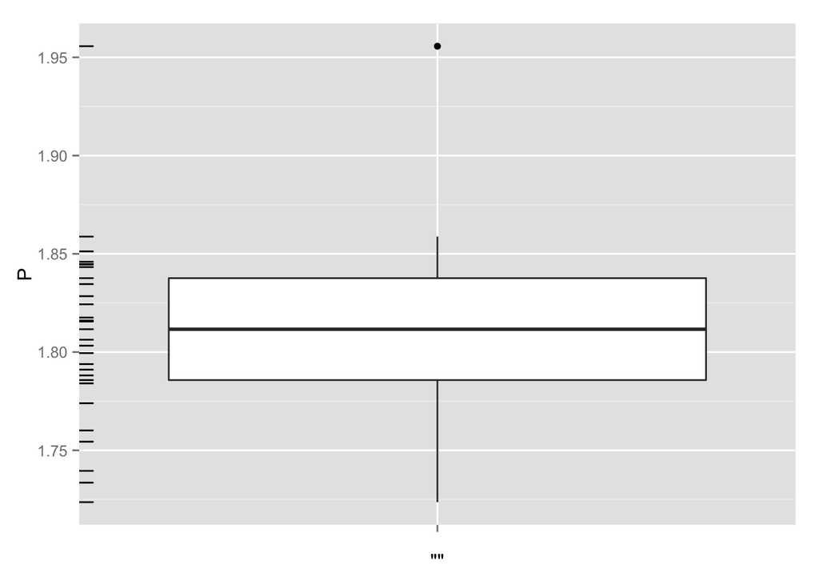

```r
p <- ggplot(data=work.run,aes(x='',y=P))+geom_boxplot()
p <- p+geom_segment(aes(yend=P),x=0.5,xend=0.52)
p
```